# Activity Monitoring Data : Peer Assesment 1

Manu Srivastav

Friday, April 17, 2015

Loading and preprocessing the data

## Part A : What is mean total number of steps taken per day?

### 1. Calculate the total number of steps taken per day

### 2. Plot a histogram of the total steps by day

```r
library(dplyr)
```

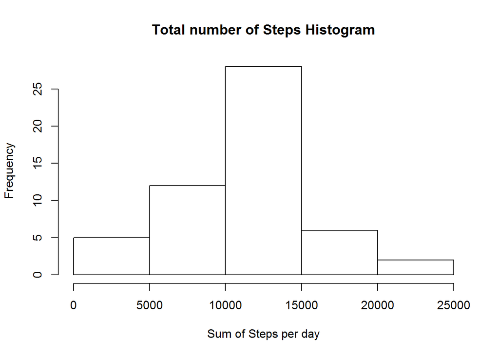

```r
## Read the file
setwd("D:/Personal/msworksOthers/201210_DocsAndResearchAndKnowledge/Coursera/data/repdata_data_activity")
ourdata <- read.csv("activity.csv")
## Ignore the NA values
ourdata1 <-na.omit(ourdata)
##use dplyr to group the steps by date
by_date <- group_by(ourdata1,date)
## use dplyr to sum the steps per day
plot_by_date <-summarize(by_date, sum(steps))
names(plot_by_date)[2] <- c("SumSteps")

## Plot a histogram of the total steps by day
hist(plot_by_date$SumSteps, xlab = "Sum of Steps per day", main = "Total number of Steps Histogram")
```

```r
## take a quick look at the summary
summary(plot_by_date)
```

```
##          date       SumSteps
##  2012-10-02: 1   Min.   :   41
##  2012-10-03: 1   1st Qu.: 8841
##  2012-10-04: 1   Median :10765
##  2012-10-05: 1   Mean   :10766
##  2012-10-06: 1   3rd Qu.:13294
##  2012-10-07: 1   Max.   :21194
##  (Other)   :47
```

```r
## Find the mean of the Steps
mymean <- round(mean(plot_by_date$SumSteps))

## Find the medean of the Steps
mymedian <- round(median(plot_by_date$SumSteps))
```

### 3 . Calculate and report the mean and median of the total number of steps taken per day

### The Mean of the total Steps is 10766

### The Medean of the total Steps is 10765

## End of Part A

## Part B : What is the average daily activity pattern??

### 1.Make a time series plot (i.e. type = “l”) of the 5-minute interval (x-axis) and the average number of steps taken, averaged across all days (y-axis)

### 2.Which 5-minute interval, on average across all the days in the dataset, contains the maximum number of steps?

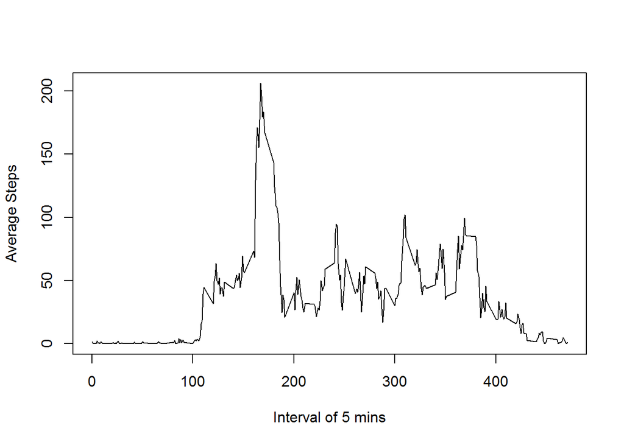

```r
library(dplyr)
## Read the file
setwd("D:/Personal/msworksOthers/201210_DocsAndResearchAndKnowledge/Coursera/data/repdata_data_activity")
ourdata <- read.csv("activity.csv")
## Ignore the NA values
ourdata1 <-na.omit(ourdata)
##use dplyr to group the steps by interval
by_interval <- group_by(ourdata1,interval)
## use dplyr to mean the steps by interval

plot_by_interval <-summarize(by_interval, mean(steps))
names(plot_by_interval)[2] <- c("AvgSteps")

## TS plot of interval and mean steps during that interval of all days
plot.ts(plot_by_interval$interval/5, plot_by_interval$AvgSteps, type="l", xlab = "Interval of 5 mins", ylab = "Average Steps")
```

```r
## take a quick look at the summary
summary(plot_by_interval)
```

```
##     interval         AvgSteps
##  Min.   :   0.0   Min.   :  0.000
##  1st Qu.: 588.8   1st Qu.:  2.486
##  Median :1177.5   Median : 34.113
##  Mean   :1177.5   Mean   : 37.383
##  3rd Qu.:1766.2   3rd Qu.: 52.835
##  Max.   :2355.0   Max.   :206.170
```

```r
## Find the max steps
mymaxAvgSteps <- max(plot_by_interval$AvgSteps)

## arrange in desc order to get the interval
##head(arrange( plot_by_interval, desc(AvgSteps)))

## Divide the interval by 5 to get the which 5 min interval had the max average steps
```

### The max Avg Steps was 206.1698 and occured in interval 167

## End of Part B

## Part C : Imputing missing values

### 1.Calculate and report the total number of missing values in the dataset (i.e. the total number of rows with NAs)

### 2.Devise a strategy for filling in all of the missing values in the dataset. The strategy does not need to be sophisticated. For example, you could use the mean/median for that day, or the mean for that 5-minute interval, etc

### 3.Create a new dataset that is equal to the original dataset but with the missing data filled in.

### 4.Make a histogram of the total number of steps taken each day and Calculate and report the mean and median total number of steps taken per day.

```r
library(dplyr)
## Read the file
setwd("D:/Personal/msworksOthers/201210_DocsAndResearchAndKnowledge/Coursera/data/repdata_data_activity")
ourdata <- read.csv("activity.csv")

## total number of rows with missing values in steps
length(which(is.na(ourdata$steps)))
```

```
## [1] 2304
```

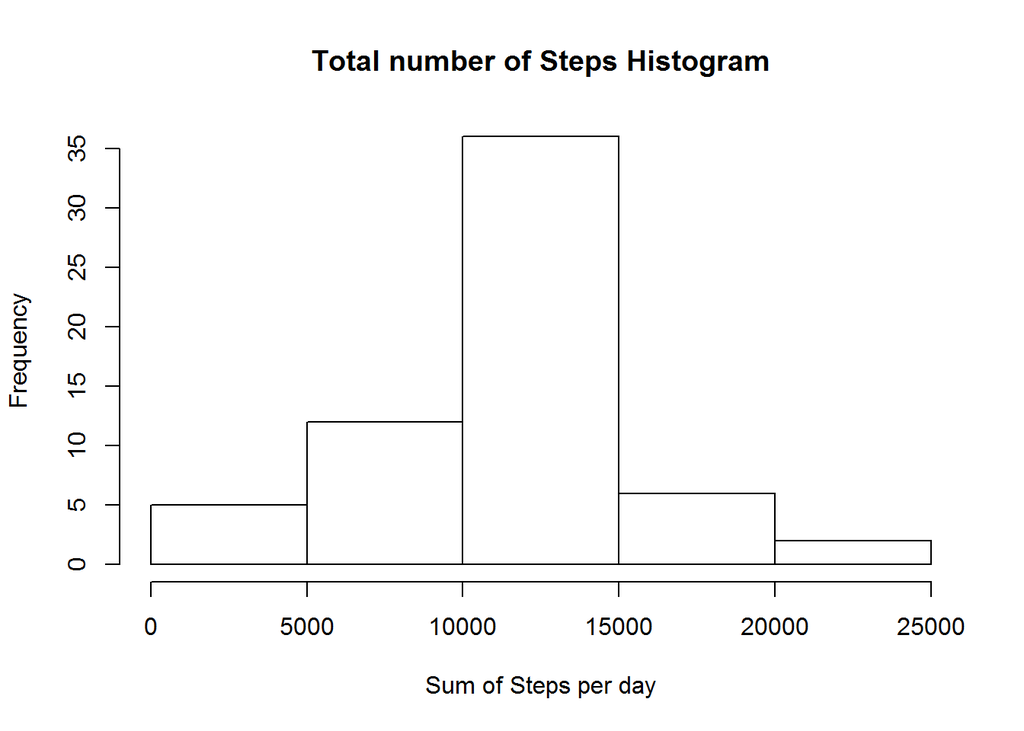

```r
totalNumberOfmissingRows <- length(which(is.na(ourdata$steps)))
ourdata1 <- ourdata
## filling the NA values in steps with  a value
## I could have used mean of the interval or mean of the day, but I preferred to used the mean of all the available steps for all the days to keep it simple and unbiased

ourdata1$steps[is.na(ourdata1$steps)] <- mean(ourdata1$steps, na.rm=TRUE)

##use dplyr to group the steps by date
by_date <- group_by(ourdata1,date)
## use dplyr to sum the steps per day
plot_by_date <-summarize(by_date, sum(steps))
names(plot_by_date)[2] <- c("SumSteps")

## Plot a histogram of the total steps by day
hist(plot_by_date$SumSteps, xlab = "Sum of Steps per day", main = "Total number of Steps Histogram")
```

```r
## take a quick look at the summary
summary(plot_by_date)
```

```
##          date       SumSteps
##  2012-10-01: 1   Min.   :   41
##  2012-10-02: 1   1st Qu.: 9819
##  2012-10-03: 1   Median :10766
##  2012-10-04: 1   Mean   :10766
##  2012-10-05: 1   3rd Qu.:12811
##  2012-10-06: 1   Max.   :21194
##  (Other)   :55
```

```r
## Find the mean of the Steps
mymean <- round(mean(plot_by_date$SumSteps))

## Find the medean of the Steps
mymedian <- round(median(plot_by_date$SumSteps))
```

### The Mean of the total Steps with NA values replaced is 10766

### The Medean of the total Steps with NA values replaced is 10766

### As we can see the Mean and Median values dont defer with filling the NA values with a fixed values of the mean of the total steps.

## End of Part C

## Part D : Are there differences in activity patterns between weekdays and weekends?

### 1.Create a new factor variable in the dataset with two levels - “weekday” and “weekend” indicating whether a given date is a weekday or weekend day.

### 2.Make a panel plot containing a time series plot (i.e. type = “l”) of the 5-minute interval (x-axis) and the average number of steps taken, averaged across all weekday days or weekend days (y-axis). See the README file in the GitHub repository to see an example of what this plot should look like using simulated data.

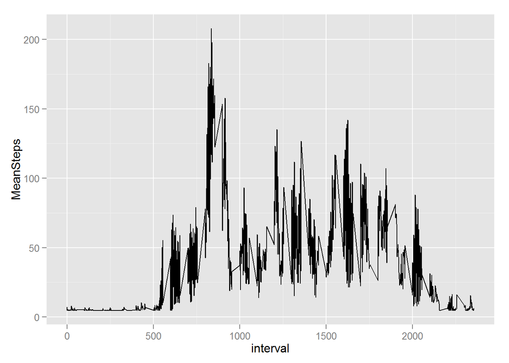

```r
library(dplyr)
library(ggplot2)
## Read the file
setwd("D:/Personal/msworksOthers/201210_DocsAndResearchAndKnowledge/Coursera/data/repdata_data_activity")
ourdata <- read.csv("activity.csv")


ourdata1 <- ourdata
## filling the NA values in steps with  a value
## I could have used mean of the interval or mean of the day, but I preferred to used the mean of all the available steps for all the days to keep it simple and unbiased

ourdata1$steps[is.na(ourdata1$steps)] <- mean(ourdata1$steps, na.rm=TRUE)

## create another df so that we dont mess up the original dataframe
ourdata3 <-ourdata1
## Add another factor column for weekday or weekend
ourdata3$weekend <- factor(weekdays(as.Date(as.character(ourdata3$date),"%Y-%m-%d")) %in% c('Sunday','Saturday'))
levels(ourdata3$weekend)[levels(ourdata3$weekend)=="1"] <- "1"
levels(ourdata3$weekend)[levels(ourdata3$weekend)=="0"] <- "0"

##use dplyr to group the steps by interval and weekend
by_interval_weekend <- group_by(ourdata3,interval, weekend)

## use dplyr to average the steps per interval
plot_by_interval_weekend<-summarize(by_interval_weekend, mean(steps))
names(plot_by_interval_weekend)[3] <- c("MeanSteps")

## Plot a Mean Steps by Interval categorized by weekend
g <- ggplot(plot_by_interval_weekend, aes(interval, MeanSteps))
p <- g + geom_line()
print(p)
```

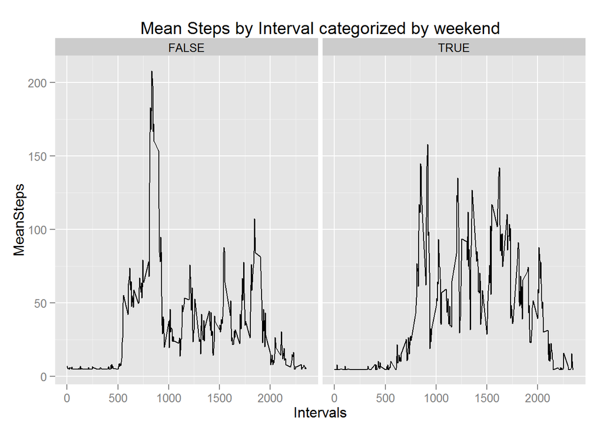

```r
g + geom_line() + facet_grid(.~weekend) + labs(x = "Intervals") + labs(y = "MeanSteps") + labs ( title = "Mean Steps by Interval categorized by weekend")
```

## End of Part D